# 2017-03-20-sentiment-analysis-of-hararis-books

So! Following my [previous blog post](https://kkulma.github.io/2017-03-07-amazon-reviews-wordcloud/) where I scraped Amazon reviews of Yuval Harari’s [*Sapiens*](https://kkulma.github.io/2017-03-07-amazon-reviews-wordcloud/) to create a wordcloud based on them, here I will compare results of [sentiment analysis](https://en.wikipedia.org/wiki/Sentiment_analysis) performed on Harari’s two books: [*Sapiens*](https://en.wikipedia.org/wiki/Sapiens:_A_Brief_History_of_Humankind) and [*Homo Deus*](https://en.wikipedia.org/wiki/Homo_Deus:_A_Brief_History_of_Tomorrow).

### **A QUICK INTRO**

For the context, *“Sapiens”* has been published originally in Hebrew in 2011. It, as *Wikipedia* puts it,

> [Sapiens] surveys the history of humankind from the evolution of archaic human species in the Stone Age up to the twenty-first century.

It quickly became a bestseller, but it still took 4 years before Harari published his most recent book, and an overnight hit, *Homo Deus*:

> Homo Deus, as opposed to the previous book, deals more with the abilities acquired by mankind (Homo sapiens) throughout the years of its existence while basing itself as the dominant being in the world, and tries to paint an image of the future of mankind, if any *[Wikipedia]*

So, in both books the historical, philosophical, economical and biological synthesis of the human species played a big role, and in this sense they are similar. Still, *Sapiens* was the first of its kind and it probably set high expectations for the follower book. Additionally, *Homo Deus* makes some bold predictions about the future of human kind in the world ruled by algorithms and AI, and any such speculation will have a very polarizing effect.

**For this reason, my prediction is that *Sapiens* will receive more positive reviews than *Homo Deus*.** And there’s only one way to find out if I’m right, so let’s get cracking!

### **SENTIMENT ANALYSIS**

```r
# load packages
library(tidyverse)
library(XML)
library(xml2)
library(tidytext)
library(knitr)
```

```r
### scaping the reviews

# product codes
sapiens_code = "1846558239"
homo_deus_code = "1910701874"

#Source funtion to Parse Amazon html pages for data
source("https://raw.githubusercontent.com/rjsaito/Just-R-Things/master/Text%20Mining/amazonscraper.R")

# extract first 12 pages of reviews for each book
pages <- 12

function_page <- function(page_num, prod_code){
  url2 <- paste0("http://www.amazon.co.uk/product-reviews/",prod_code,"/?pageNumber=", page_num)
  doc2 <- read_html(url2)

  reviews <- amazon_scraper(doc2, reviewer = F, delay = 2)
  reviews
}

sapiens_reviews <- map2(1:pages, sapiens_code, function_page) %>% bind_rows()
sapiens_reviews$comments <- gsub("\\.", "\\. ", sapiens_reviews$comments) #add space after each full stop

homo_deus_reviews <- map2(1:pages, homo_deus_code, function_page) %>% bind_rows()
homo_deus_reviews$comments <- gsub("\\.", "\\. ", homo_deus_reviews$comments) #add space after each full stop

knitr::kable(head(homo_deus_reviews, 2))
```

| title | author | date | ver.purchase | format | stars | comments | helpful |
| --- | --- | --- | --- | --- | --- | --- | --- |
| A fascinating read. A worthy successor to Harari’s Sapiens. | Benjamin | 20 September 2016 | 0 | Format: Hardcover | 5 | Yuval Noah Harari had a tough act to follow after his outstanding book ‘Sapiens: A brief history of humankind’, which raised (and answered) questions like: Why did human beings became all-too-powerful… | 71 |
| Five Stars | Bookish-Em | 15 September 2016 | 0 | Format: Kindle Edition | 5 | This is a profoundly shocking piece of writing, a tactic which Yuval Noah Harari uses to great effect in getting readers to think about society today. The book is ostensibly about the future of mankin… | 37 |

Looks like a good start to me! Next, I’ll analyse and compare word sentiments between the two books. To achieve this, I write a function that breaks down review sentences into separate words and removes common English stop words, such as *you*, *at*, *above*, etc.

```r
### sentiment analysis ####

# Split a column with the reviews into separate words

words_function <- function(df){
  df_words <- df %>%
  select(date, comments, stars) %>%
  unnest_tokens(word, comments)

  data("stop_words")

  df_words <- df_words %>%
    anti_join(stop_words)

  df_words
}

sapiens_words <- words_function(sapiens_reviews)
homo_deus_words <- words_function(homo_deus_reviews)
```

Now, there are several approaches to quantifying the amount of different sentiments in text (and thus using different relevant R lexicons) : you can associate a word with a given emotion, like joy, sadness, fear etc. (**NRC lexicon**), express whether a word is positive or negative (**bing lexicon**) or give it a numeric score between -5 and 5, where values under 0 indicate a negative sentiment and above 0 - the positive. Words scoring close to or equal zero are neutral (**afinn lexicon**).

```r
get_sentiments("bing") %>% head
```

```
## # A tibble: 6 × 2
##         word sentiment
##        <chr>     <chr>
## 1    2-faced  negative
## 2    2-faces  negative
## 3         a+  positive
## 4   abnormal  negative
## 5    abolish  negative
## 6 abominable  negative
```

```r
get_sentiments("nrc") %>% head
```

```
## # A tibble: 6 × 2
##        word sentiment
##       <chr>     <chr>
## 1    abacus     trust
## 2   abandon      fear
## 3   abandon  negative
## 4   abandon   sadness
## 5 abandoned     anger
## 6 abandoned      fear
```

```r
get_sentiments("afinn") %>% head
```

```
## # A tibble: 6 × 2
##         word score
##        <chr> <int>
## 1    abandon    -2
## 2  abandoned    -2
## 3   abandons    -2
## 4   abducted    -2
## 5  abduction    -2
## 6 abductions    -2
```

All I need to do now is to use `left_join()` to add both lexicons to my data:

```r
sapiens_words <- sapiens_words %>%
  left_join(get_sentiments("bing"), by = "word") %>%
  left_join(get_sentiments("afinn"), by = "word") %>%
  mutate(book = "Sapiens") %>% unique()

homo_deus_words <- homo_deus_words %>%
  left_join(get_sentiments("bing"), by = "word") %>%
  left_join(get_sentiments("afinn"), by = "word") %>%
  mutate(book = "Homo Deus") %>% unique()

all_words <- bind_rows(sapiens_words, homo_deus_words)
all_words %>% arrange(sentiment) %>% head() %>% kable()
```

| date | stars | word | sentiment | score | book |
| --- | --- | --- | --- | --- | --- |
| 3 November 2014 | 5 | uncertain | negative | -1 | Sapiens |
| 3 November 2014 | 5 | poverty | negative | -1 | Sapiens |
| 3 November 2014 | 5 | anxiety | negative | -2 | Sapiens |
| 3 November 2014 | 5 | disastrous | negative | -3 | Sapiens |
| 3 November 2014 | 5 | burns | negative | NA | Sapiens |
| 3 November 2014 | 5 | havoc | negative | -2 | Sapiens |

```r
all_words %>%
  group_by(book, stars) %>%
  summarize(n_stars = n()) %>%
  group_by(book) %>%
  mutate(n_reviews = sum(n_stars),
         percent = paste0(round(n_stars*100/n_reviews, 0), "%")) %>%
  select(-c(n_stars, n_reviews)) %>%
  spread(stars, percent)
```

```
## Source: local data frame [2 x 6]
## Groups: book [2]
##
##        book   `1`   `2`   `3`   `4`   `5`
## *     <chr> <chr> <chr> <chr> <chr> <chr>
## 1 Homo Deus    3%    8%    5%   32%   52%
## 2   Sapiens    6%    9%   20%   23%   42%
```

Is the same trend shown in the sentiment score?

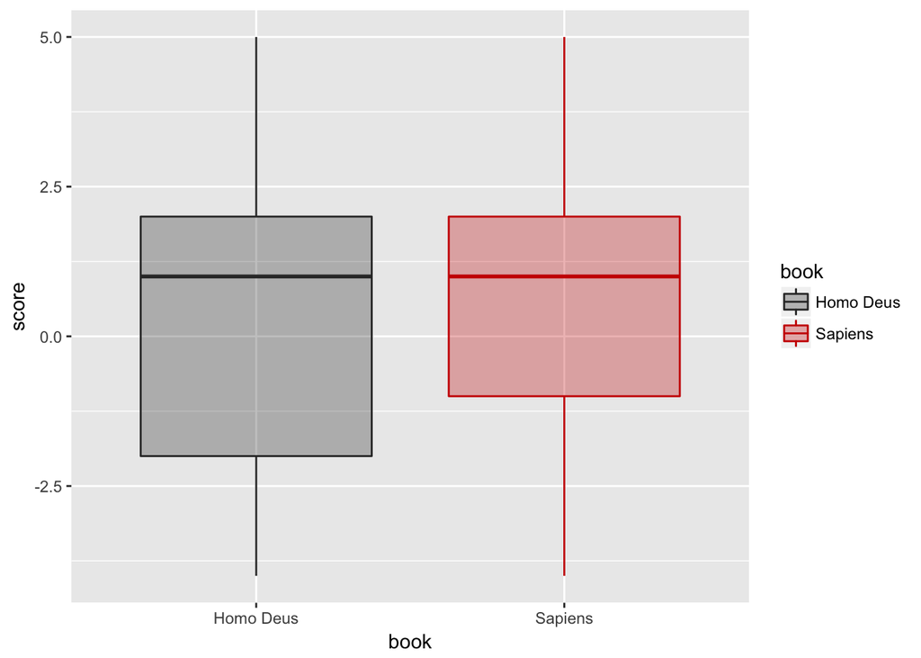

```r
all_words %>%
  ggplot(aes(x= book, y = score, color = book, fill = book)) +
  geom_boxplot(outlier.shape=NA, alpha = 0.3) + #avoid plotting outliers twice
  scale_color_manual(values=c("#333333", "#CC0000")) +
  scale_fill_manual(values=c("#333333", "#CC0000"))
```

Not at all! Distribution of *afnn* sentiment score for both books looks very similar. Does it mean that the star number reflects different level of positivity in those books? Let’s have a look

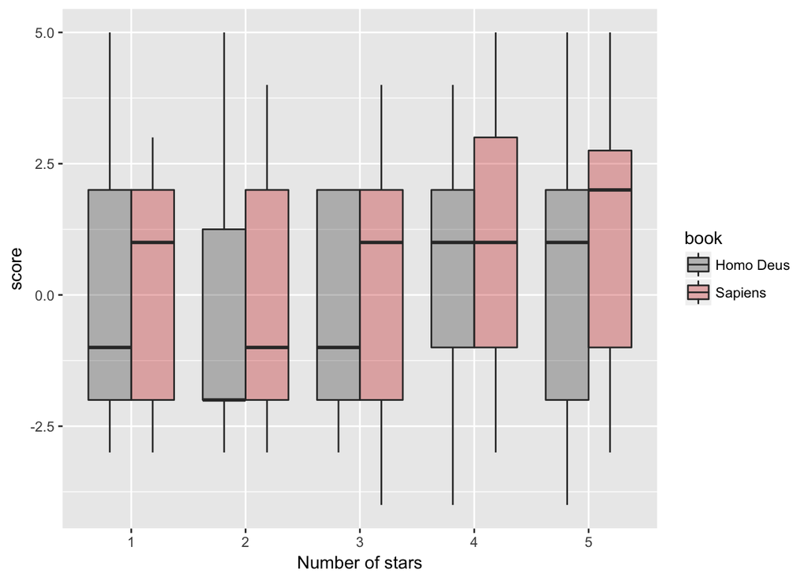

```r
### average sentiment score per star

all_words %>%
  ggplot(aes(as.factor(stars), score)) +
  geom_boxplot(aes(fill = book), alpha = 0.3) +
  xlab("Number of stars")+
    scale_color_manual(values=c("#333333", "#CC0000")) +
  scale_fill_manual(values=c("#333333", "#CC0000"))
```

```r
## ratio of positive / negative words per review

all_words %>%
  filter(!is.na(sentiment)) %>%
  group_by(book, sentiment) %>%
  summarise(n = n() ) %>%
  group_by(book) %>%
  mutate(sum = sum(n),
         percent = paste0(round(n*100/sum, 0), "%")) %>%
  select(-c(n, sum)) %>%
  spread(sentiment, percent)
```

```
## Source: local data frame [2 x 3]
## Groups: book [2]
##
##        book negative positive
## *     <chr>    <chr>    <chr>
## 1 Homo Deus      48%      52%
## 2   Sapiens      40%      60%
```

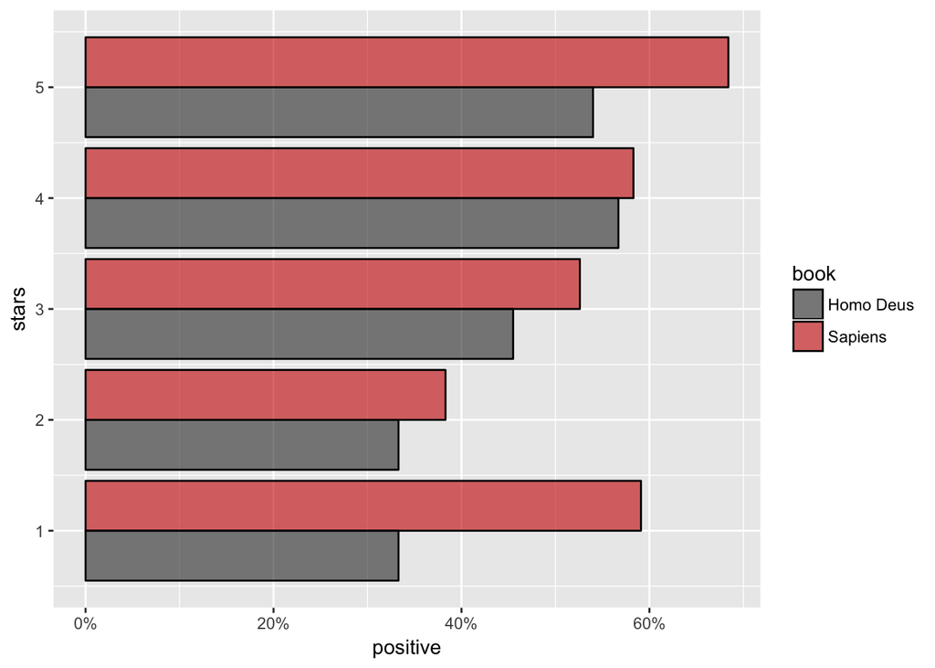

```r
### ratio of positive / negative words per star per review

all_words %>%
  filter(!is.na(sentiment)) %>%
  group_by(book, stars, sentiment) %>%
  summarise(n = n()) %>%
  group_by(book, stars) %>%
  mutate(sum = sum(n),
         percent = paste0(round(n*100/sum, 0), "%"),
         percent2 = round(n/sum, 3)) %>%
  select(-c(n, sum, percent)) %>%
  spread(sentiment, percent2) %>%
  ggplot(aes(x = stars, y = positive, fill = book)) +
  geom_bar(stat = "identity", position = position_dodge(), colour="black", alpha = 0.6) +
  scale_y_continuous(labels = scales::percent) +
   scale_color_manual(values=c("#333333", "#CC0000")) +
  scale_fill_manual(values=c("#333333", "#CC0000")) +
  coord_flip()
```

It’s all good so far, but comparing sentiments based on separate words can sometimes give misleading results, as such analysis does not take account very well for negations (e.g. *I am *not* passionate about singing*.) or amplifiers (*I *really* like this song*), etc. So, I used [`sentimentR` package](https://github.com/trinker/sentimentr) to compare sentiments of whole sentences.

```r
#### scoring sentences with sentimentr ####
  #  install.packages("devtools")
devtools::install_github("trinker/lexicon")
devtools::install_github("trinker/sentimentr")
## combining data.frames
sapiens_reviews <- sapiens_reviews %>%
      mutate(book = "Sapiens")

homo_deus_reviews <- homo_deus_reviews %>%
      mutate(book = "Homo Deus")

all_reviews <-bind_rows(sapiens_reviews, homo_deus_reviews)
out2 <- with(all_reviews, sentiment_by(comments, book))
```

`sentimentR` is a great little gem for text mining: it’s very fast, performs tokenization within the library (no need to call `tidytext::unnest_tokens()` separately), gives an option to group results by other variables and produces pretty graphs :)

```r
# sentiment scores by sentence
head(out2)
```

```
##         book word_count        sd ave_sentiment
## 1: Homo Deus      15305 0.3527297     0.1605253
## 2:   Sapiens      10469 0.4803393     0.2250817
```

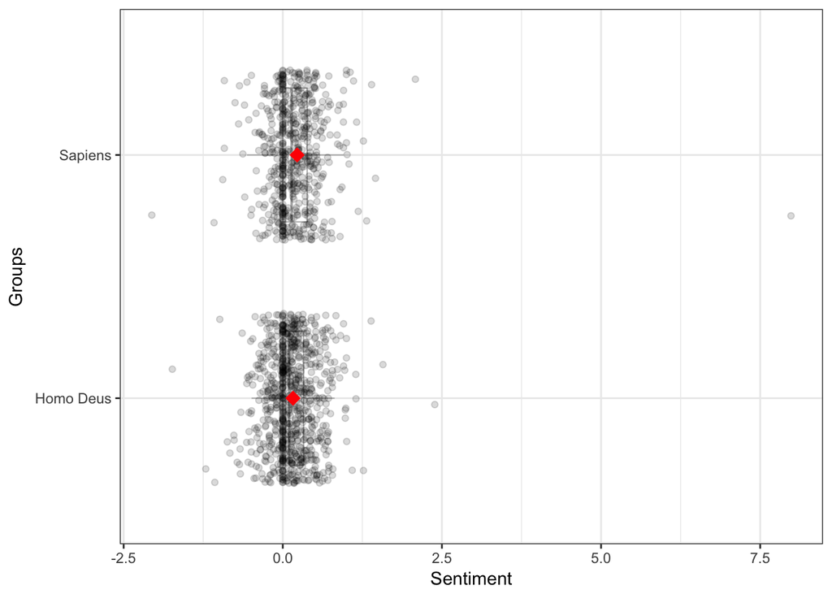

```r
# plotting sentiment scores by sentence
plot(out2)
```

Again, like with previous approaches, sentence - level sentiment looks very similar for both books, perhaps with *Sapiens* being marginally more positive. However, the really interesting stuff starts when we look at those sentiments grouped by the book **AND** the number of stars:

```r
out3 <- with(all_reviews, sentiment_by(comments, list(book, stars)))
out3
```

```
##          book stars word_count        sd ave_sentiment
##  1: Homo Deus     1        564 0.2321610  -0.070320687
##  2: Homo Deus     2       1152 0.3108673   0.005753164
##  3: Homo Deus     3        884 0.3049826   0.107059168
##  4: Homo Deus     4       5005 0.2887481   0.212188021
##  5: Homo Deus     5       7700 0.3915794   0.172690069
##  6:   Sapiens     1        592 0.3110479   0.043965984
##  7:   Sapiens     2        800 0.4312018   0.083074344
##  8:   Sapiens     3       2211 0.3394592   0.114966796
##  9:   Sapiens     4       2255 0.3504161   0.207529348
## 10:   Sapiens     5       4611 0.5737318   0.306837387
```

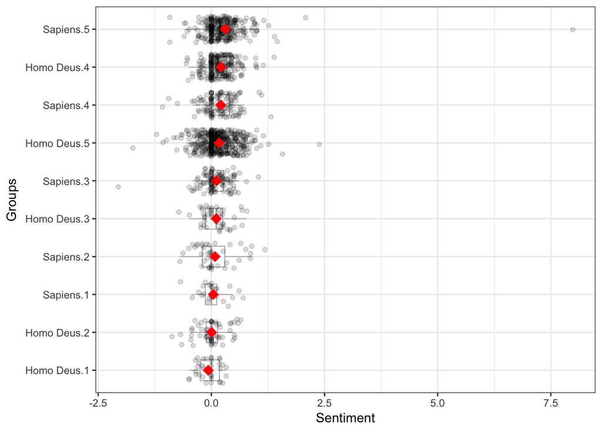

```r
plot(out3)
```

Now, it becomes clear how naive my predictions were about comparing sentiment scores betweeen the two books! Obviously, when comparing clearly bad and good books you will find striking differences in reviews’ sentiments, but when comparing two highly regarded books written by the same author it’s clear that there will be nuances and complexities to it.

##### **TAKE HOME POINTS**

1. *Homo Deus* received more positive (4 & 5-star) reviews than *Sapiens*, however
2. both books had very similar sentiment score on the word- and sentence-level.
3. It was mainly due to *Sapiens* receiving higher sentiment scores for both, most positive and most negative reviews.
4. overall, different approaches to sentiment analysis showed consistent results, which is reassuring :-)

**funny fact from writing this blog post:** throughout the process I’ve been writing *Deus Ex* or `deus_ex` instead of *Homo Deus* and `homo_deus` respectively, and I only realised it after my partner read the final version of this post… oops!